# Music & Mental Health

Jan Moskal i Szymon Makulec

2025-05-31

## Wstęp

#### Cel projektu

Głównym celem analizy jest opracowanie modelu klasyfikacyjnego, który umożliwi przewidywanie poziomu nasilenia zmiennej `Depression` (niskie, średnie, wysokie). Chcemy sprawdzić, czy dane dotyczące sposobu słuchania muzyki, codziennych nawyków oraz częstotliwości słuchania konkretnych gatunków muzycznych itd. mogą być pomocne w przewidywaniu poziomu samopoczucia psychicznego, a konkretnie nasilenia objawów depresyjnych.

#### Opis danych

Dane pochodzą ze zbioru dostępnego na stronie [Kaggle](https://www.kaggle.com/datasets/catherinerasgaitis/mxmh-survey-results/data), który zawiera odpowiedzi respondentów na temat ich zwyczajów związanych ze słuchaniem muzyki oraz samooceny zdrowia psychicznego. Dane te mogą być pomocne w identyfikacji potencjalnych zależności między stylem życia muzycznego a samopoczuciem psychicznym.

#### Opis zmiennych

| Zmienna | Opis | Typ |
| --- | --- | --- |
| Timestamp | Data i czas przesłania formularza | datetime |
| Age | Wiek respondenta | numeric |
| Primarystreamingservice | Główna platforma streamingowa używana przez respondenta | factor |
| Hoursperday | Liczba godzin dziennie, przez które respondent słucha muzyki | numeric |
| Whileworking | Czy respondent słucha muzyki podczas nauki/pracy? | factor |
| Instrumentalist | Czy respondent regularnie gra na instrumencie? | factor |
| Composer | Czy respondent komponuje muzykę? | factor |
| Favgenre | Ulubiony gatunek muzyczny respondenta | factor |
| Exploratory | Czy respondent aktywnie odkrywa nowych artystów/gatunki? | factor |
| Foreignlanguages | Czy respondent regularnie słucha muzyki z tekstami w języku, którego nie zna biegle? | factor |
| BPM | Liczba uderzeń na minutę w ulubionym gatunku muzycznym | numeric |
| Frequency[Classical] | Jak często respondent słucha muzyki klasycznej? | factor |
| Frequency[Country] | Jak często respondent słucha muzyki country? | factor |
| Frequency[EDM] | Jak często respondent słucha muzyki EDM? | factor |
| Frequency[Folk] | Jak często respondent słucha muzyki folkowej? | factor |
| Frequency[Gospel] | Jak często respondent słucha muzyki gospel? | factor |
| Frequency[Hiphop] | Jak często respondent słucha muzyki hip-hop? | factor |
| Frequency[Jazz] | Jak często respondent słucha muzyki jazzowej? | factor |
| Frequency[Kpop] | Jak często respondent słucha muzyki K-pop? | factor |
| Frequency[Latin] | Jak często respondent słucha muzyki latynoskiej? | factor |
| Frequency[Lofi] | Jak często respondent słucha muzyki lo-fi? | factor |
| Frequency[Metal] | Jak często respondent słucha muzyki metalowej? | factor |
| Frequency[Pop] | Jak często respondent słucha muzyki pop? | factor |
| Frequency[R&B] | Jak często respondent słucha muzyki R&B? | factor |
| Frequency[Rap] | Jak często respondent słucha muzyki rap? | factor |
| Frequency[Rock] | Jak często respondent słucha muzyki rockowej? | factor |
| Frequency[Videogame music] | Jak często respondent słucha muzyki z gier wideo? | factor |
| Anxiety | Nasilenie stanów lękowych w skali 0–10 | ordered factor |
| Depression | Nasilenie depresji w skali 0–10 | factor |
| Insomnia | Nasilenie problemów ze snem w skali 0–10 | ordered factor |
| OCD | Nasilenie zaburzeń obsesyjno-kompulsyjnych w skali 0–10 | ordered factor |
| Music effects | Subiektywny wpływ muzyki na zdrowie psychiczne | factor |
| Permissions | Zgoda na wykorzystanie danych | factor |

## Wstępne przygotowanie danych

### Wczytanie i obróbka danych

```r
df <- read_csv("mxmh_survey_results.csv", col_names = TRUE)
```

#### Usuwanie zbędnych zmiennych

```r
df <- df %>%
        select(-c(Timestamp, Anxiety, Insomnia, OCD, `Music effects`, Permissions))
```

Usuwamy zmienne niezwiązane bezpośrednio z analizowaną problematyką (Timestamp, Permissions). Pozostałe zmienne są poza zakresem analizy lub same mogą być przewidywane, więc nie powinny być predyktorami.

```r
glimpse(df)
```

```
## Rows: 736
## Columns: 27
## $ Age                            <dbl> 18, 63, 18, 61, 18, 18, 18, 21, 19, 18,…
## $ `Primary streaming service`    <chr> "Spotify", "Pandora", "Spotify", "YouTu…
## $ `Hours per day`                <dbl> 3.0, 1.5, 4.0, 2.5, 4.0, 5.0, 3.0, 1.0,…
## $ `While working`                <chr> "Yes", "Yes", "No", "Yes", "Yes", "Yes"…
## $ Instrumentalist                <chr> "Yes", "No", "No", "No", "No", "Yes", "…
## $ Composer                       <chr> "Yes", "No", "No", "Yes", "No", "Yes", …
## $ `Fav genre`                    <chr> "Latin", "Rock", "Video game music", "J…
## $ Exploratory                    <chr> "Yes", "Yes", "No", "Yes", "Yes", "Yes"…
## $ `Foreign languages`            <chr> "Yes", "No", "Yes", "Yes", "No", "Yes",…
## $ BPM                            <dbl> 156, 119, 132, 84, 107, 86, 66, 95, 94,…
## $ `Frequency [Classical]`        <chr> "Rarely", "Sometimes", "Never", "Someti…
## $ `Frequency [Country]`          <chr> "Never", "Never", "Never", "Never", "Ne…
## $ `Frequency [EDM]`              <chr> "Rarely", "Never", "Very frequently", "…
## $ `Frequency [Folk]`             <chr> "Never", "Rarely", "Never", "Rarely", "…
## $ `Frequency [Gospel]`           <chr> "Never", "Sometimes", "Never", "Sometim…
## $ `Frequency [Hip hop]`          <chr> "Sometimes", "Rarely", "Rarely", "Never…
## $ `Frequency [Jazz]`             <chr> "Never", "Very frequently", "Rarely", "…
## $ `Frequency [K pop]`            <chr> "Very frequently", "Rarely", "Very freq…
## $ `Frequency [Latin]`            <chr> "Very frequently", "Sometimes", "Never"…
## $ `Frequency [Lofi]`             <chr> "Rarely", "Rarely", "Sometimes", "Somet…
## $ `Frequency [Metal]`            <chr> "Never", "Never", "Sometimes", "Never",…
## $ `Frequency [Pop]`              <chr> "Very frequently", "Sometimes", "Rarely…
## $ `Frequency [R&B]`              <chr> "Sometimes", "Sometimes", "Never", "Som…
## $ `Frequency [Rap]`              <chr> "Very frequently", "Rarely", "Rarely", …
## $ `Frequency [Rock]`             <chr> "Never", "Very frequently", "Rarely", "…
## $ `Frequency [Video game music]` <chr> "Sometimes", "Rarely", "Very frequently…
## $ Depression                     <dbl> 0, 2, 7, 7, 2, 8, 8, 3, 0, 2, 7, 0, 3, …
```

Po usunięciu niepotrzebnych zmiennych w zbiorze zostało 27 kolumn, z czego większość to narazie zmienne tekstowe, jednak po zmianach będą to zmienne czynnikowe (często uporządkowane). Mamy też kilka zmiennych numerycznych. Mamy 736 obserwacje, gdzie każda oznacza wypełnienie ankiety przez jedną osobę.

#### Ustawianie odpowiedniej kolejności poziomów w zmiennych dotyczących częstotliwości słuchania konkretnych gatunków

```r
custom_levels <- c("Never", "Rarely", "Sometimes", "Very frequently")

df <- df %>%
        mutate(across(`Frequency [Classical]`:`Frequency [Video game music]`, function(x) factor(x, levels = custom_levels, ordered = TRUE)))
```

Wszystkie kolumny dotyczące częstotliwości słuchania danych zamieniamy na uporządkowane kategoryczne, ponieważ widać w ich przypadku naturalny porządek kategorii.

#### Ustawienie pozostałych zmiennych typu tekstowego na zmienne kategoryczne

```r
df <- df %>%
        mutate(across(`While working`:`Foreign languages`, as.factor),
               `Primary streaming service` = as.factor(`Primary streaming service`))
```

Pozostałe zmienne tekstowe zamieniamy na zmienne kategoryczne. Są tutaj zmienne, które przyjmują wiele wartości tzn. `Primary streaming service`, `Fav genre` oraz zmienne binarne (pozostałe).

#### Zapisanie ramki danych po przekształceniach

```r
#saveRDS(df, "df.rds")
```

#### Zamiana zmiennej objaśnianej z typu numerycznego na typ kategoryczny z trzema kategoriami

```r
quantiles <- quantile(df$Depression, probs = c(0.33, 0.66), na.rm = TRUE)
```

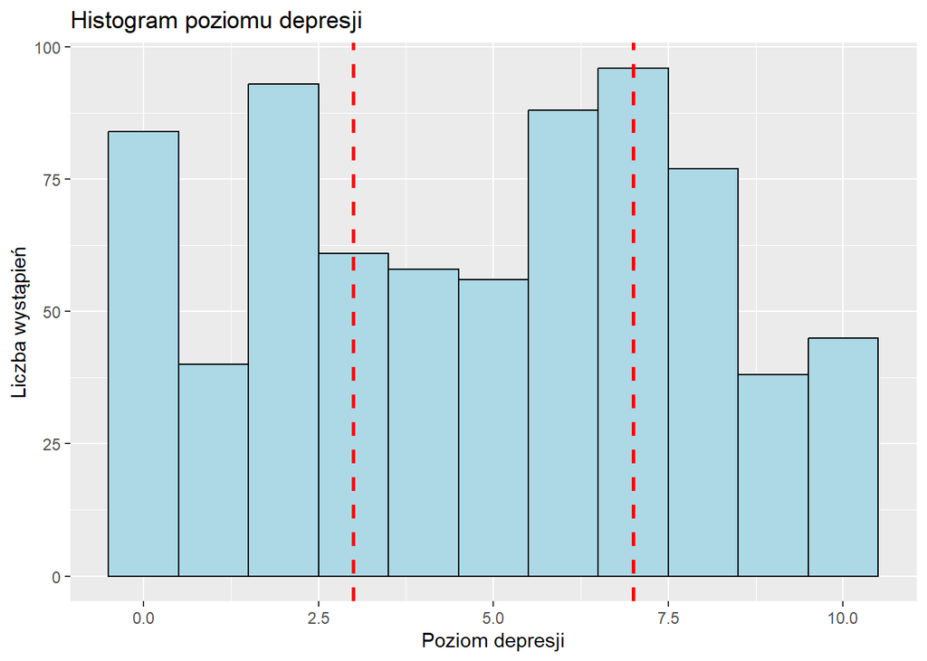

```r
df <- df %>%
  mutate(Depression = case_when(
    Depression <= quantiles[1] ~ "Low", # 0-3
    Depression > quantiles[1] & Depression < quantiles[2] ~ "Medium", # 4-6
    Depression >= quantiles[2] ~ "High" # 7-10
  ))
```

Rozpatrywanie zmiennej poziomu depresji w skali 0–10 byłoby problematyczne ze względu na dużą liczbę klas oraz wątpliwą interpretowalność drobnych różnic. Różnice między niskimi wartościami (np. 0, 1, 2) mogą być nieistotne, ponieważ osoby zaznaczające te poziomy zazwyczaj chcą jedynie zaznaczyć brak objawów depresyjnych. Podobnie wartości wysokie mogą być traktowane ogólnie jako wskazanie poważniejszych problemów, niezależnie od dokładnej liczby. Choć skrajne wartości mogą świadczyć o większej pewności odpowiedzi, zdecydowaliśmy się na przekształcenie tej zmiennej w trzy kategorie: Low, Medium i High. Podziału dokonano na podstawie kwantyli.

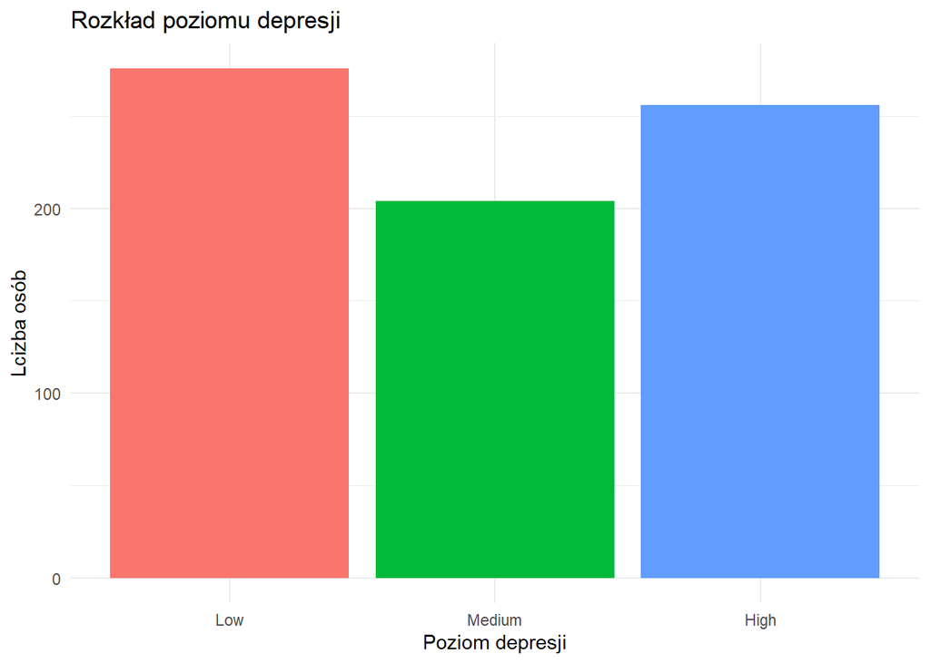

Jak widać, dane są dość zbalansowane – liczba obserwacji dla skrajnych poziomów (niskiego i wysokiego) jest nieco większa. Pozostawiamy ten podział bez zmian, ponieważ mniejsza liczba obserwacji w kategorii średniej nie jest problemem – to właśnie w tej grupie trudniej jednoznacznie określić stan respondenta. W przypadku poziomów niskiego i wysokiego można z większym prawdopodobieństwem założyć, że dana osoba odpowiednio nie doświadcza lub wyraźnie doświadcza objawów.

#### Zapisanie ramki danych po czyszczeniu i transformacji danych do EDA

```r
#saveRDS(df, "df_EDA.rds")
```

Na koniec zapisujemy zbiór, który posłuży nam do eksploracyjnej analizy danych.

## Eksploracyjna analiza danych

### Statystyki opisowe

#### Wczytywanie danych

```r
data <- readRDS("df_EDA.rds")
df <- readRDS("df.rds")
```

#### Podstawowe statystyki opisowe dla zmiennych numerycznych

```
##       Age        Hours per day         BPM             Depression
##  Min.   :10.00   Min.   : 0.000   Min.   :0.00e+00   Min.   : 0.000
##  1st Qu.:18.00   1st Qu.: 2.000   1st Qu.:1.00e+02   1st Qu.: 2.000
##  Median :21.00   Median : 3.000   Median :1.20e+02   Median : 5.000
##  Mean   :25.21   Mean   : 3.573   Mean   :1.59e+06   Mean   : 4.796
##  3rd Qu.:28.00   3rd Qu.: 5.000   3rd Qu.:1.44e+02   3rd Qu.: 7.000
##  Max.   :89.00   Max.   :24.000   Max.   :1.00e+09   Max.   :10.000
##  NA's   :1                        NA's   :107
```

Warto zwrócić uwagę, że w dwóch kolumnach numerycznych występują braki danych – w `Age` tylko jedna, natomiast w `BPM` aż 107 obserwacji. Dodatkowo, w zmiennej `BPM` pojawiaja się wartość (lub wartości) znacznie odbiegająca od typowego zakresu BPM, zapewne jest to błąd. Wszystkie te kwestie zostaną w dalszej części odpowiednio przetworzone i rozwiązane.

#### Wykres macierzy korelacji dla zmiennych numerycznych

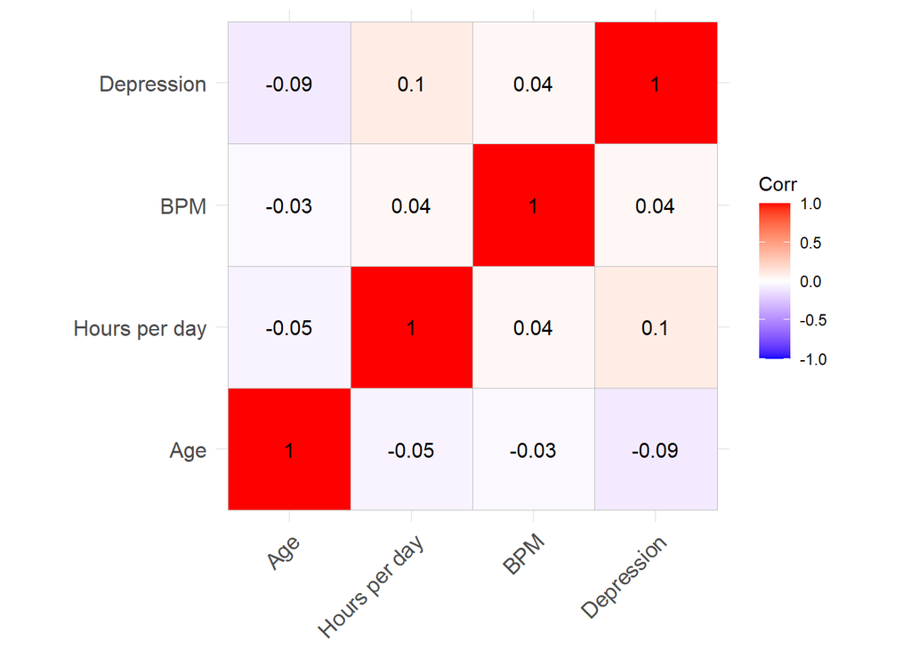

Z analizy macierzy korelacji wynika, że nie występują istotne korelacje ani między zmiennymi objaśniającymi, ani pomiędzy nimi a zmienną objaśnianą – żadna wartość nie przekracza 0.1. Może to świadczyć o braku liniowych zależności w danych, co potencjalnie utrudnia skuteczne modelowanie i prognozowanie zmiennej objaśnianej.

#### Zestawienie liczby braków danych

```
## # A tibble: 7 × 2
##   Zmienna                   `Liczba braków`
##   <chr>                               <int>
## 1 BPM                                   107
## 2 Instrumentalist                         4
## 3 Foreign languages                       4
## 4 While working                           3
## 5 Age                                     1
## 6 Primary streaming service               1
## 7 Composer                                1
```

W zbiorze danych występują braki w siedmiu zmiennych. Najwięcej braków odnotowano w zmiennej `BPM` (107), co będzie wymagać specjalnego potraktowania, zapewne imputacji. Pozostałe zmienne zawierają pojedyncze braki: `Instrumentalist` i `Foreign languages` po 4, `While working` – 3, `Age`, `Primary streaming service` i `Composer` – po 1. W tych sytuacjach planujemy usunięcie odpowiednich wierszy lub zastąpienie braków ustalonymi wartościami.

### Wykresy dotyczące zmiennych opisujących respondentów i ich ogólne zwyczaje muzyczne

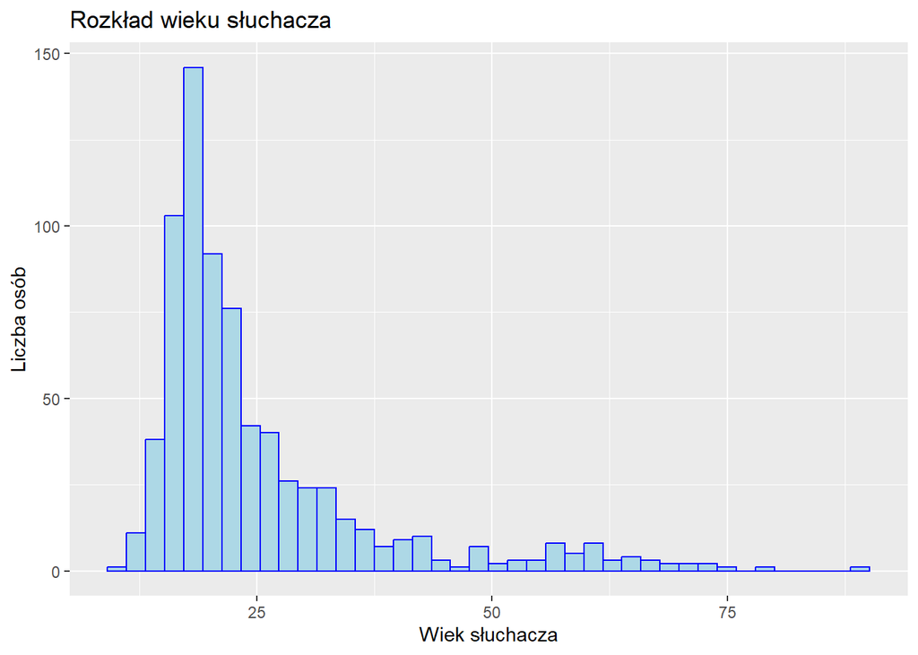

Wiek słuchaczy jest prawostronnie asymetryczny, z większością osób w przedziale 18-30 lat. Widać również trochę osób w wieku 50+.

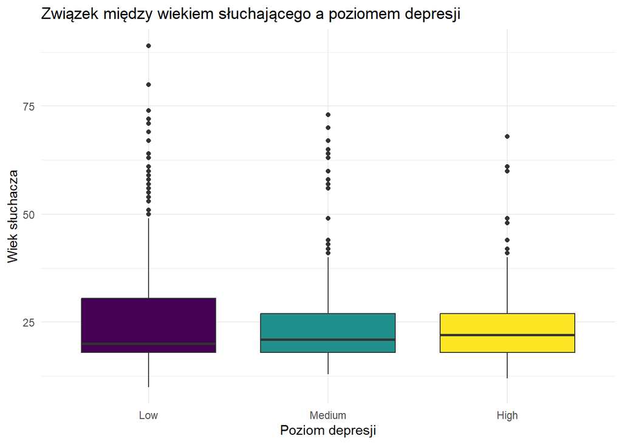

Dla niskiego poziomu depresji mamy największą różnorodność wieku słuchaczy co można zobaczyć po odległości między kwartylami. Dla średniego i wysokiego poziomu depresji mamy bardzo podobne rozkłady wieku. Im wyższy poziom depresji tym mediana wieku jest wyższa jednak nie jest ona dużo większa więc nie uznajemy tego za istotną różnicę.

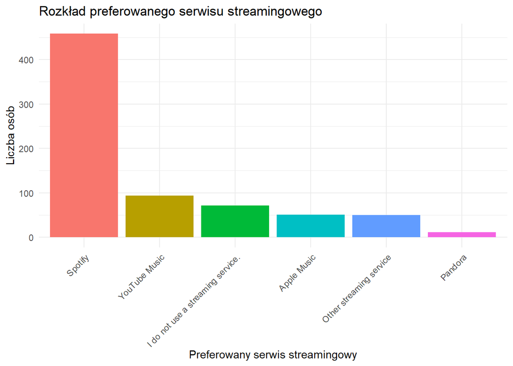

Większość słuchaczy korzysta z Spotify, a następnie z YouTube i Apple Music. Co ciekawe jest również trzecia co do wielkości grupa słuchaczy, która nie słucha muzyki w serwisach streamingowych.

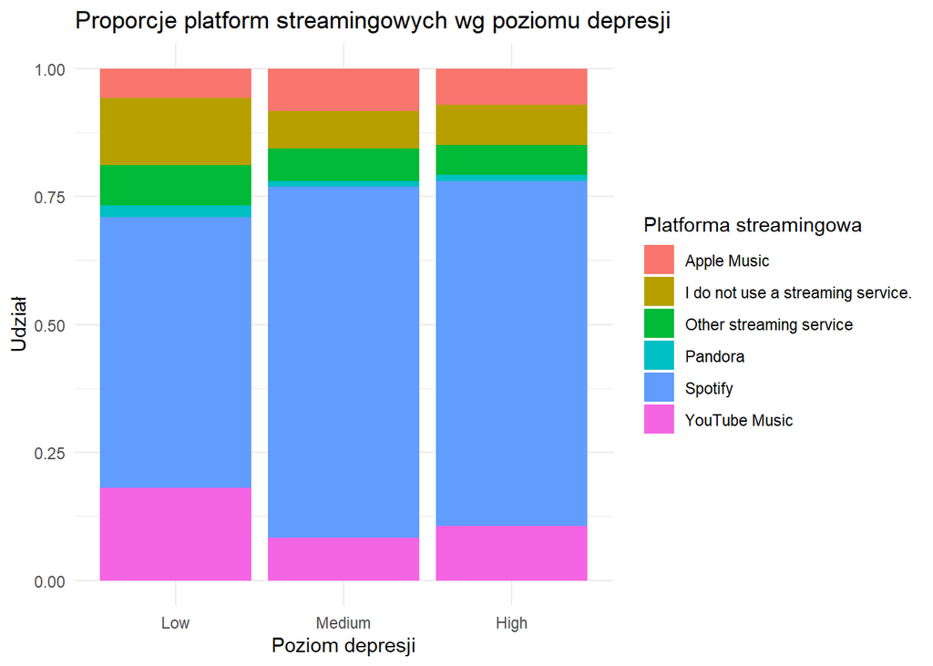

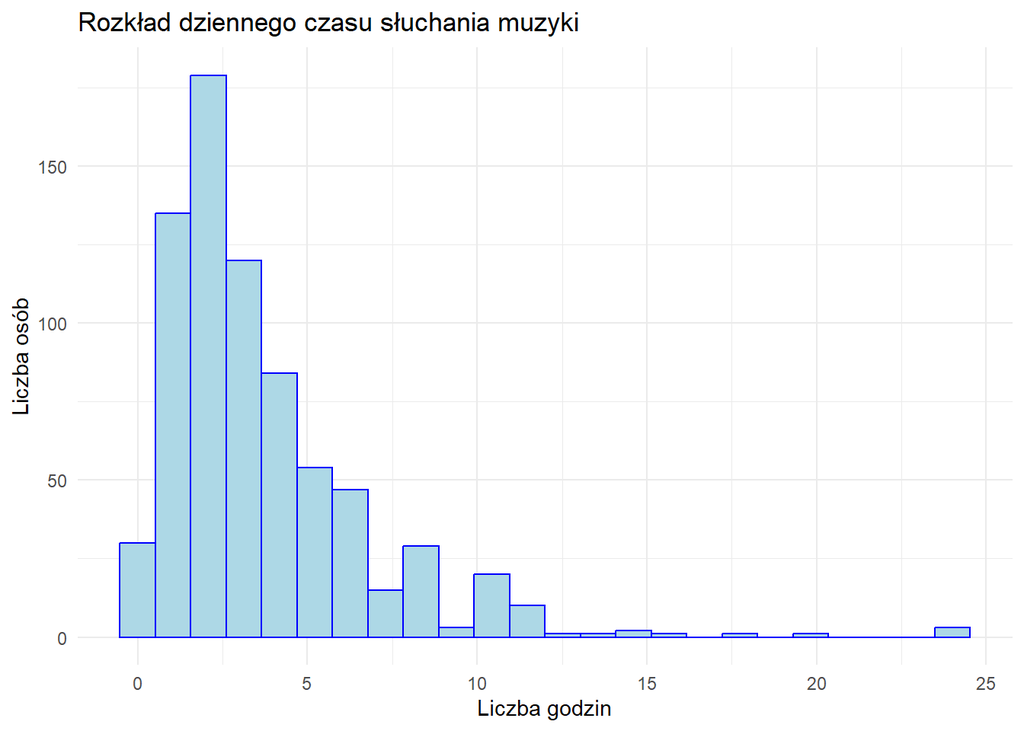

Czas słuchania muzyki jest prawostronnie asymetryczny, z większością osób słuchających muzyki od 1 do 4 godzin dziennie. Widać również kilka osób słuchających muzyki przez ponad 10 godzin dziennie.

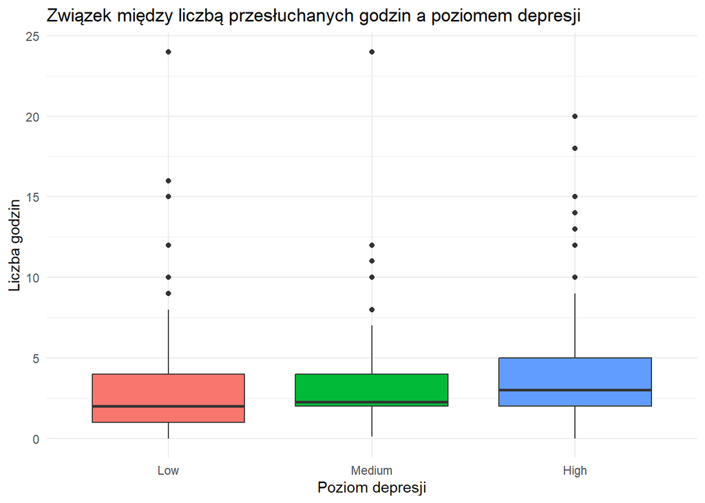

Osoby z wyższym poziomem depresji mają tendencję do słuchania muzyki przez więcej godzin dziennie niż te z niższym poziomem depresji.

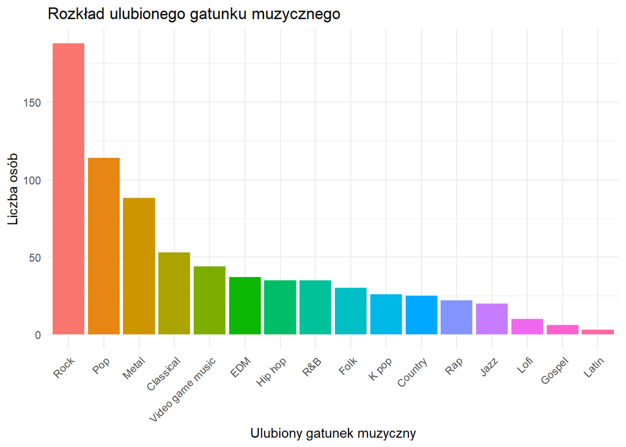

Ulubionymi gatunkami respondentów są głównie Rock, Pop oraz Metal.

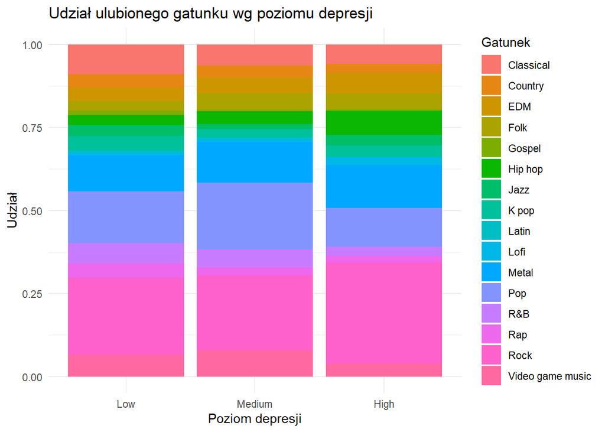

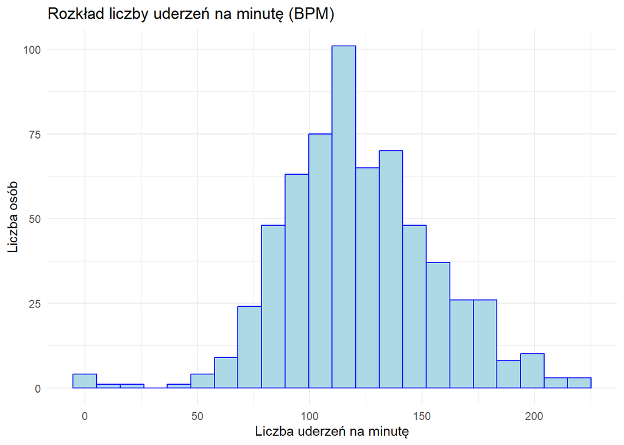

Liczba uderzeń na minutę jest w miarę symetryczna. Widoczne są obserwacje podejrzane jak BPM równe 0. Wartość BPM oscyluje wokół 120.

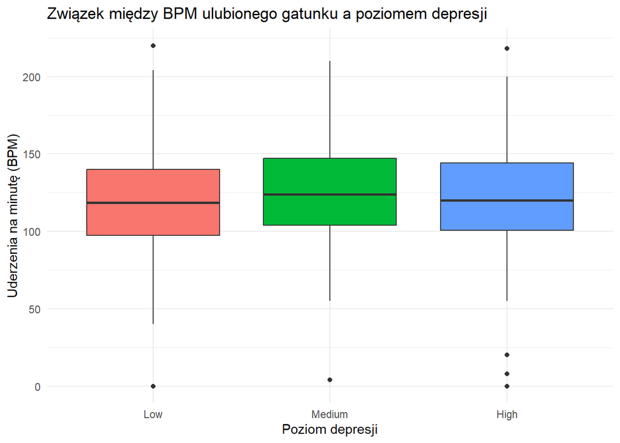

Nie widać znaczącego wpływu BPM na poziom depresji. Istnieje jedynie podejrzenie, że osoby z niskim poziomem depresji słuchają muzyki o średnio niższym BPM.

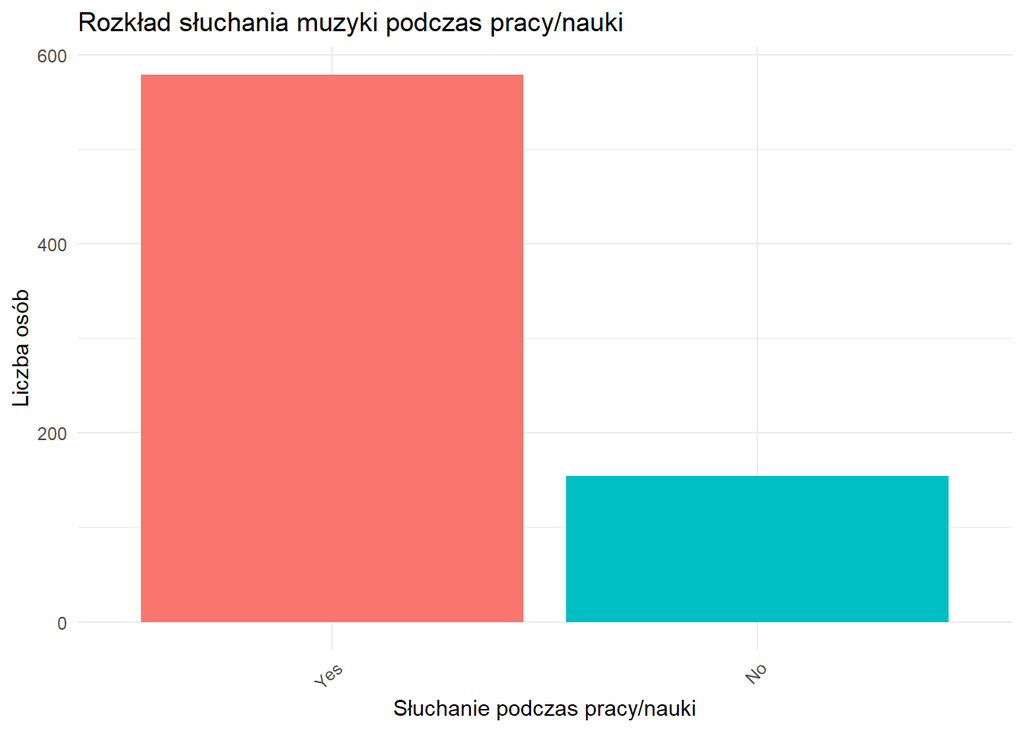

Znacząca większość osób słucha muzyki podczas pracy lub nauki.

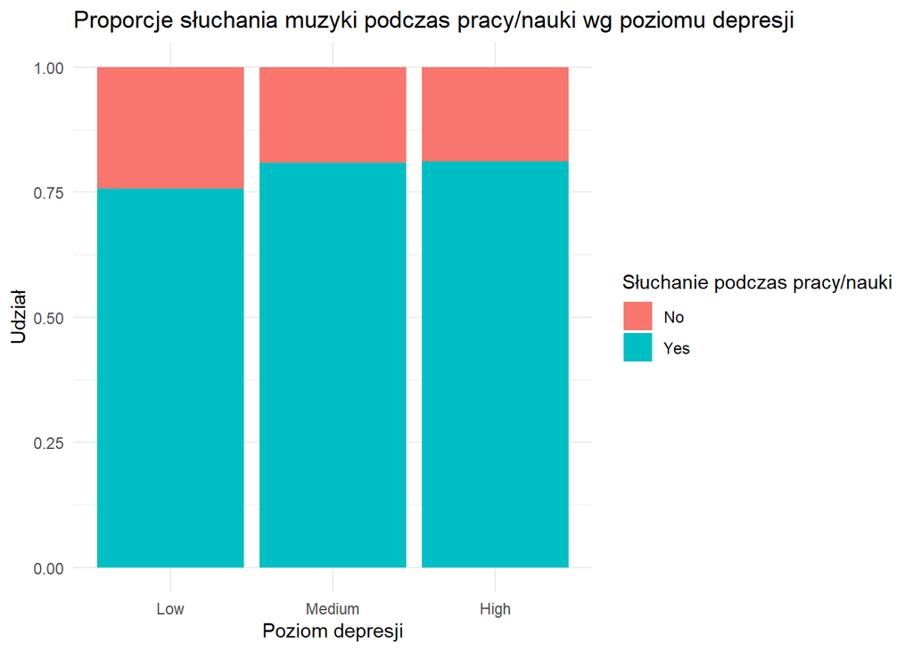

Osoby z wyższym poziomem depresji częściej słuchają muzyki podczas pracy lub nauki.

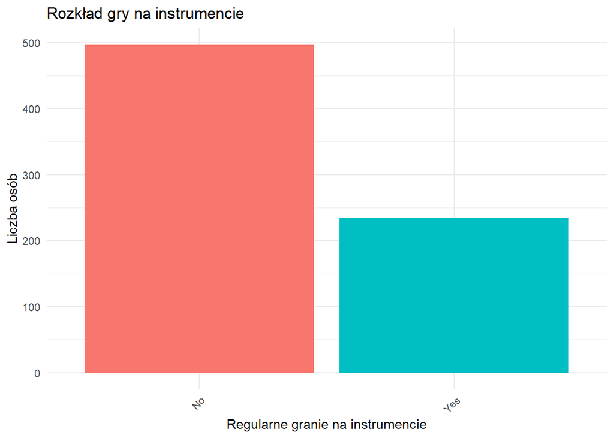

Jak można było się spodziewać znacząca większość osób nie gra na instrumencie. Jednakże ilość osób grających na instrumentach jest i tak dosyć duża.

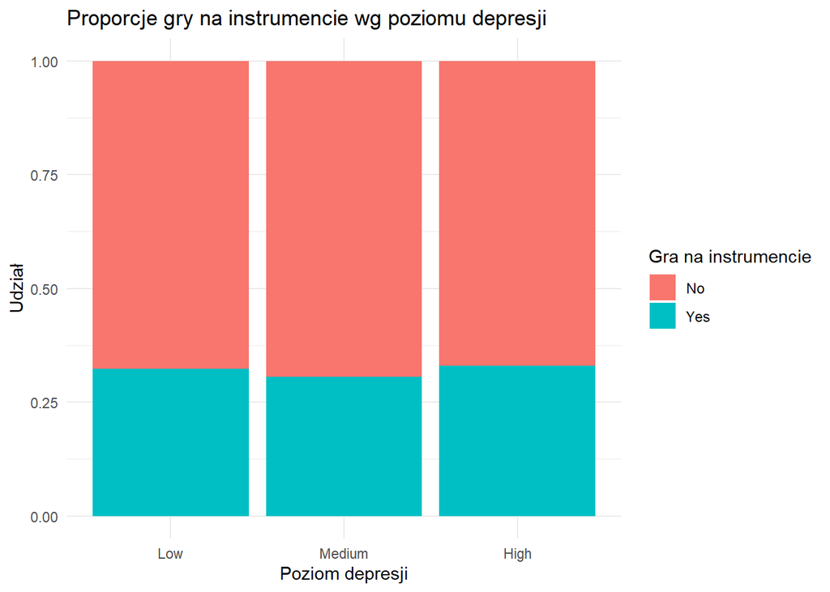

We wszystkich grupach ilość osób grających na instrumencie jest zbliżona.

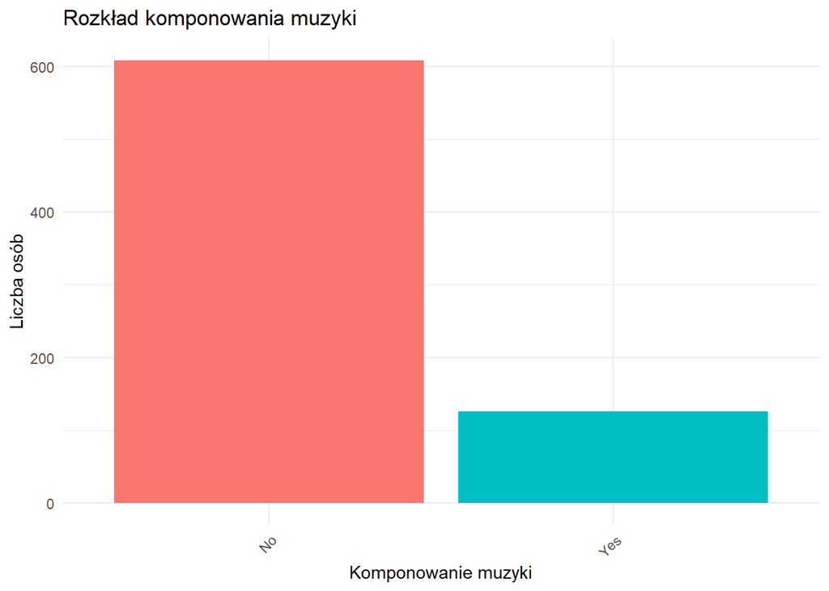

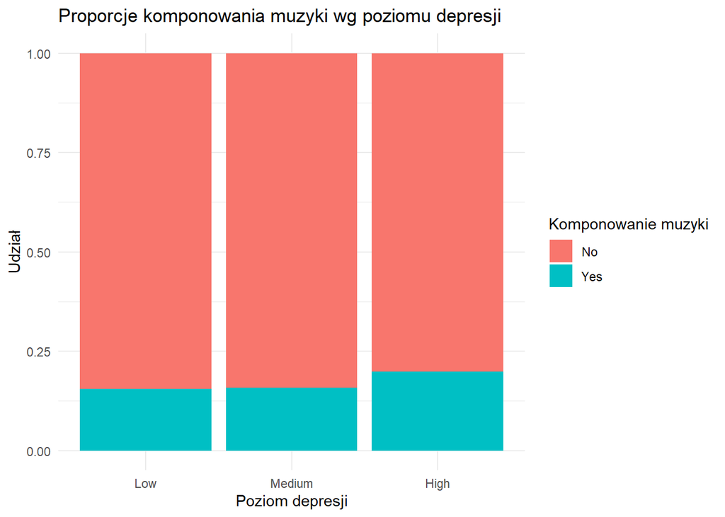

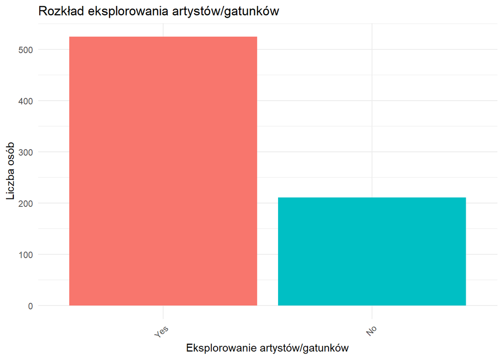

Około 520 osób aktywnie eksploruje nowe gatunki oraz artystów. Około 210 osób tego nie czyni.

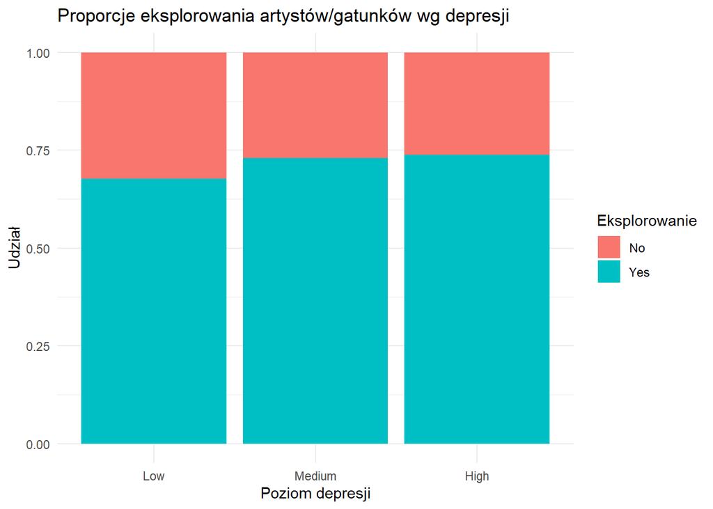

Osoby z wyższym poziomem depresji częściej eksplorują nowych artystów i gatunki muzyczne.

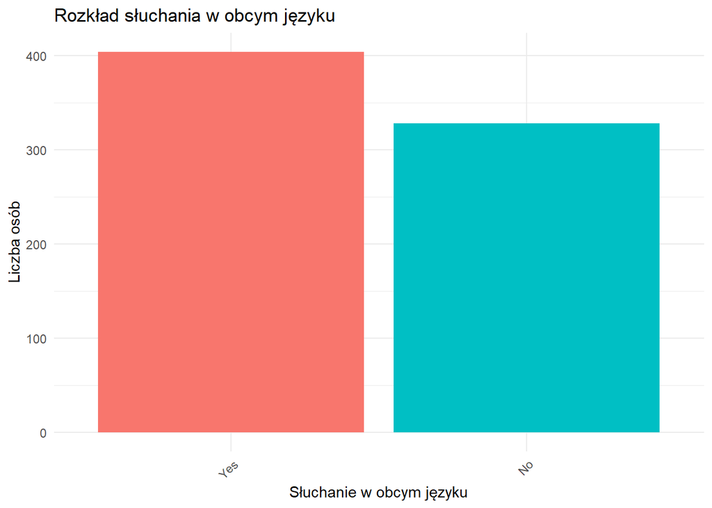

Około 400 osób słucha muzyki w języku obcym zaś około 330 osób słucha muzyki jedynie w swoim ojczystym języku.

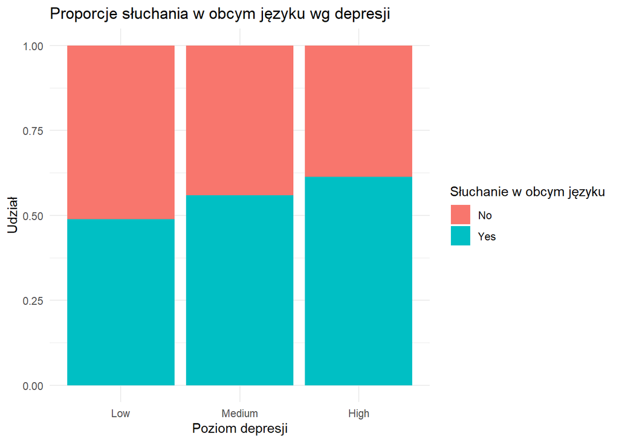

Wraz ze wzrostem depresji rośnie liczba osób słuchających muzyki w obcym języku.

### Wykresy dotyczące zmiennych częstotliwości słuchania konkretnych gatunków

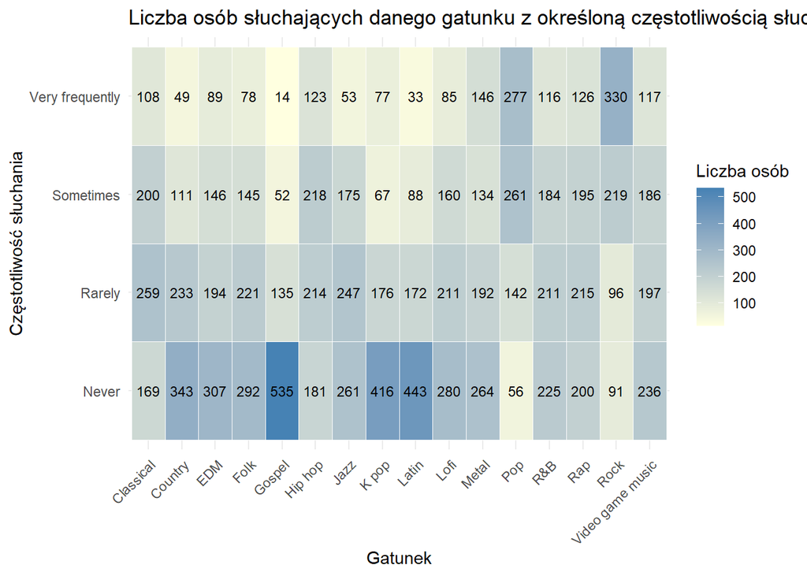

Najwięcej osób bardzo często słucha muzyki pop i rock, co nie dziwi – są to jedne z najpopularniejszych gatunków muzycznych. Rzadko zdarza się natomiast, by respondenci w ogóle nie słuchali tych dwóch stylów. Z kolei niewielki odsetek badanych deklaruje częste słuchanie takich gatunków jak gospel, country, latin czy jazz. Może to wynikać z ich mniejszej popularności wśród młodszych odbiorców oraz postrzegania ich jako bardziej egzotycznych. Warto również zauważyć, że bardzo wiele osób nigdy nie słuchało muzyki gospel, k-popu, latin lub country, co może być związane z kulturowym lub religijnym kontekstem tych gatunków.Możliwy wpływ ma również dostępność tych gatunków w mediach i na platformach streamingowych, a także język utworów – gatunki nieanglojęzyczne mogą być mniej przystępne.

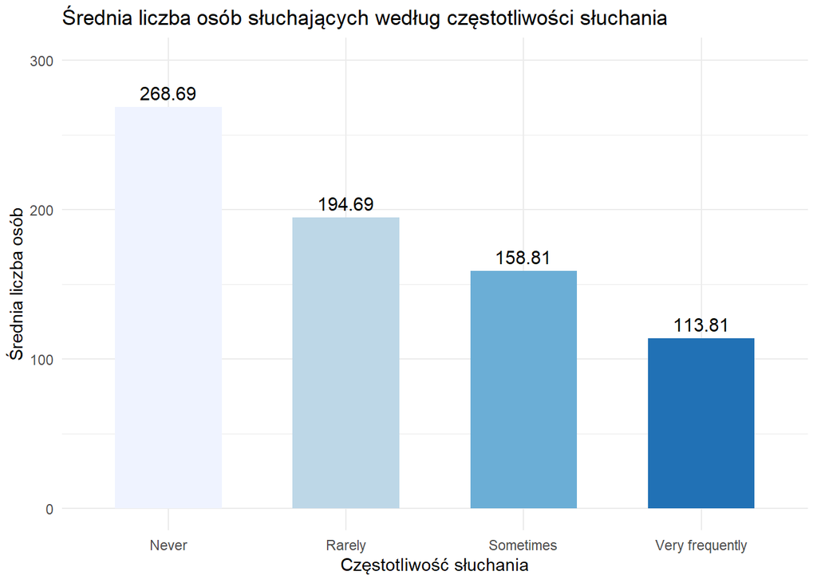

Średnia liczba osób przypadająca na poszczególne poziomy częstotliwości słuchania maleje wraz ze wzrostem intensywności słuchania. Najwięcej osób średnio deklaruje, że nigdy nie słucha danego gatunku muzyki (268,69), a najmniej – że słucha go bardzo często (113,81). Może to sugerować, że większość gatunków muzycznych jest słuchana okazjonalnie lub wcale, a intensywne słuchanie ogranicza się do wybranych, popularnych stylów.

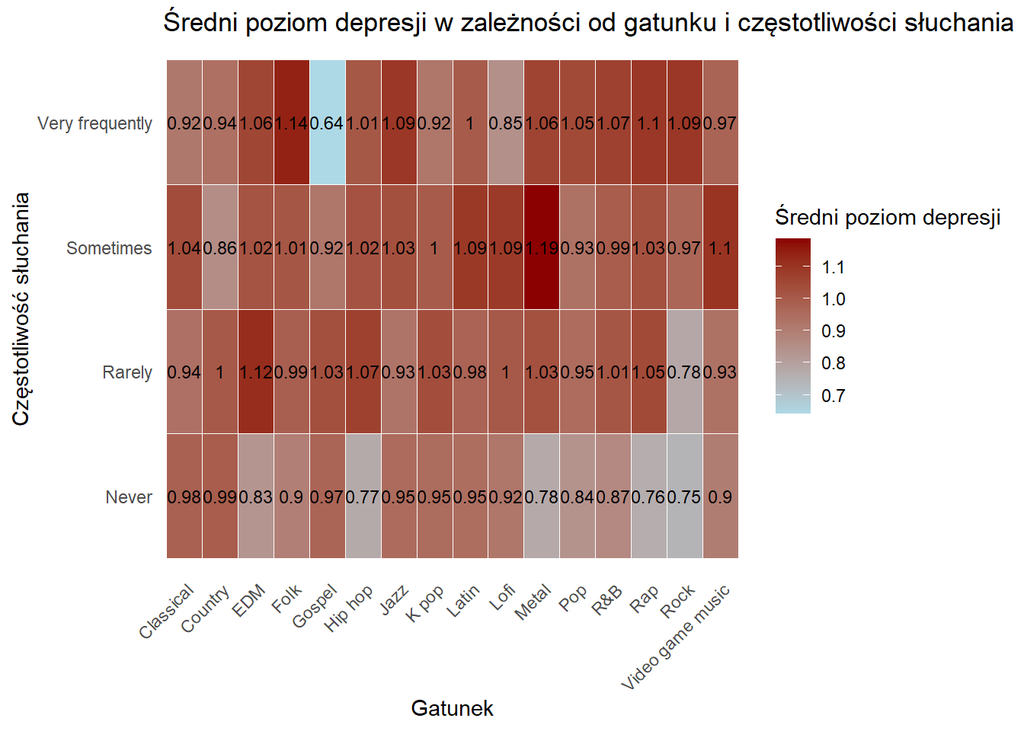

Po zdekodowaniu poziomu depresji (Low = 0, Medium = 1, High = 2) zauważalne są niewielkie, ale interesujące różnice w średnich wartościach w zależności od gatunku i częstotliwości słuchania muzyki. Najwyższy poziom depresji (1.19) występuje u osób czasami słuchających metalu, natomiast najniższy (0.64) – u osób bardzo często słuchających gospel, co może sugerować możliwy wpływ duchowości lub wieku słuchaczy. Osoby unikające gatunków takich jak metal, rap czy hip-hop również charakteryzują się niższym średnim poziomem depresji, choć może to wynikać z innych czynników – jak wiek, styl życia czy preferencje kulturowe. Ogólnie poziomy depresji oscylują wokół wartości 1, a różnice nie są duże, jednak dla niektórych gatunków zauważalne są pewne wzorce.

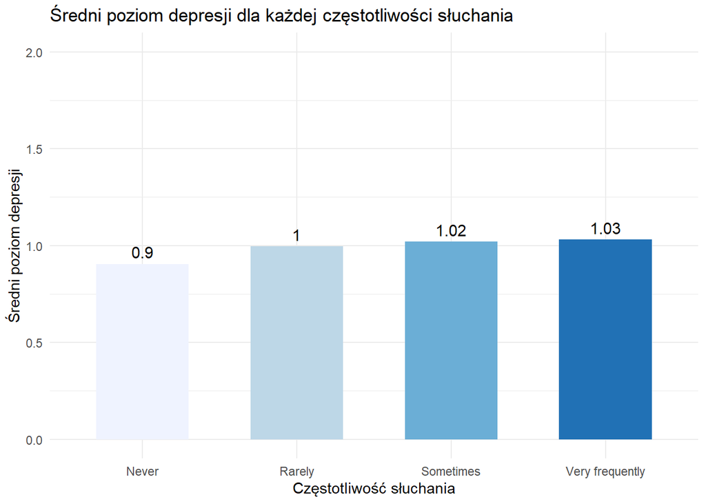

Średni poziom depresji nieznacznie (nieistotnie) wzrasta wraz ze zwiększającą się częstotliwością słuchania muzyki. Choć różnice są niewielkie, może to sugerować, że osoby częściej sięgające po muzykę – zwłaszcza intensywnie – częściej też deklarują średni lub wysoki poziom depresji. Może to wynikać z faktu, że muzyka bywa wykorzystywana jako forma wsparcia emocjonalnego, szczególnie przez osoby zmagające się z pogorszonym samopoczuciem. To jednak tak drobne zmiany, że trudno wyciągać z nich pewne wnioski.

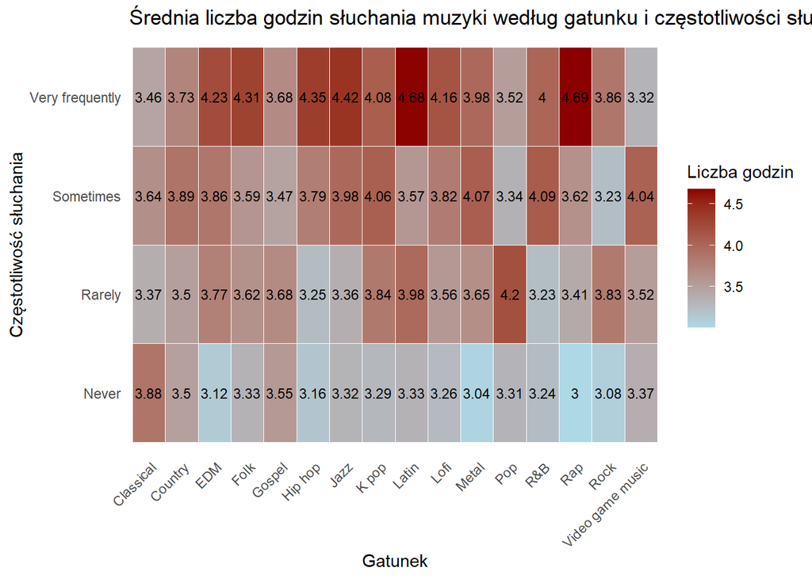

Z wykresu wynika, że jeśli dana osoba deklaruje częste słuchanie muzyki danego gatunku, to więcej czasu jej poświęca ogółem — co jest zgodne z intuicją. Gatunki takie jak rap, muzyka latynoska i hip-hop osiągają najwyższe średnie wartości godzin wśród osób słuchających muzyki bardzo często, co może świadczyć o ich intensywnej konsumpcji. Warto jednak zwrócić uwagę, że nawet osoby, które deklarują brak kontaktu z danym gatunkiem, często ogółem spędzają na słuchaniu muzyki znaczną liczbę godzin. Może to sugerować, że ich preferencje są silnie skierowane ku innym gatunkom, a nie że unikają muzyki jako takiej. Różnice w średniej liczbie godzin między grupami częstotliwości są widoczne, ale w wielu przypadkach niezbyt duże.

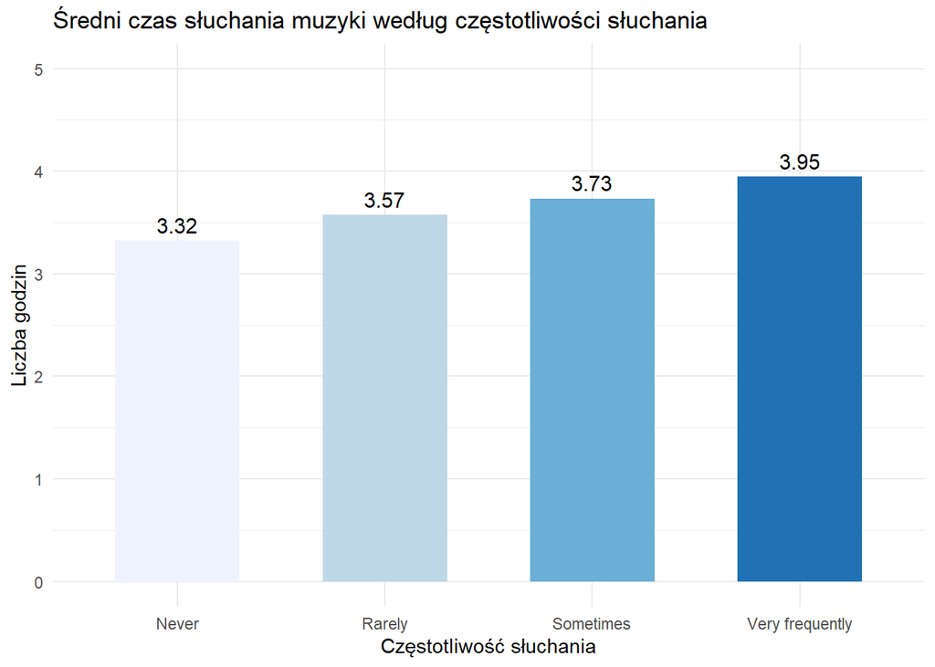

Zanim przejdziemy do analizy, warto zaznaczyć, że słupek „Never” nie odnosi się do osób, które w ogóle nie słuchają muzyki, lecz do liczby gatunków, których ktoś nie słucha wcale. Osoby deklarujące bardzo częste słuchanie muzyki spędzają na tym najwięcej czasu, podczas gdy osoby słuchające jej rzadziej poświęcają jej odpowiednio mniej czasu. Każda kolejna grupa częstotliwości charakteryzuje się nieco wyższym średnim czasem słuchania, co świadczy o spójności deklaracji z rzeczywistym zaangażowaniem czasowym. Może to również potwierdzać, że częstotliwość słuchania stanowi dobry wskaźnik ogólnej intensywności kontaktu z muzyką. Wzrost ten jest jednak stosunkowo nieduży.

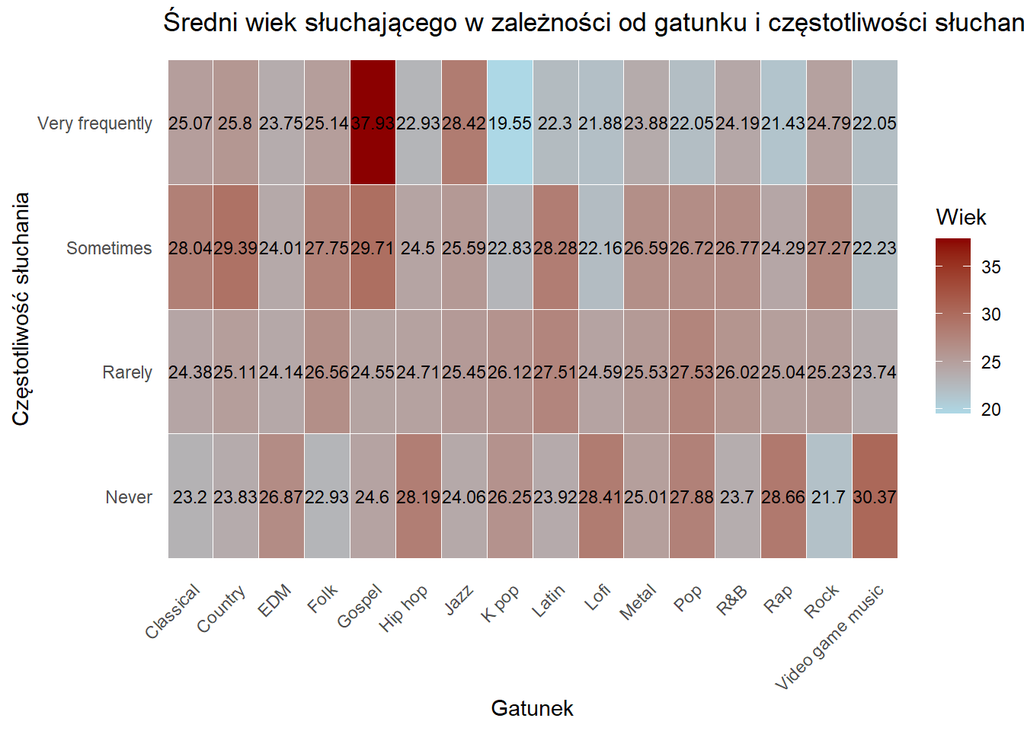

Ogólnie można zauważyć, że osoby, które słuchają muzyki bardzo często, są zazwyczaj młodsze od tych, które robią to rzadziej lub deklarują brak kontaktu z danym gatunkiem. Najniższe średnie wieki występują wśród intensywnych słuchaczy gatunków takich jak K-pop, pop, rap, video game music czy lofi, co potwierdza ich popularność wśród młodszych odbiorców. Z kolei najwyższe wartości średniego wieku pojawiają się wśród osób słuchających częściej muzyki klasycznej, gospel, country czy rocka, co może wskazywać na większe zainteresowanie tymi gatunkami wśród starszych grup. Wzorce te są spójne z ogólnymi trendami demograficznymi w odbiorze muzyki.

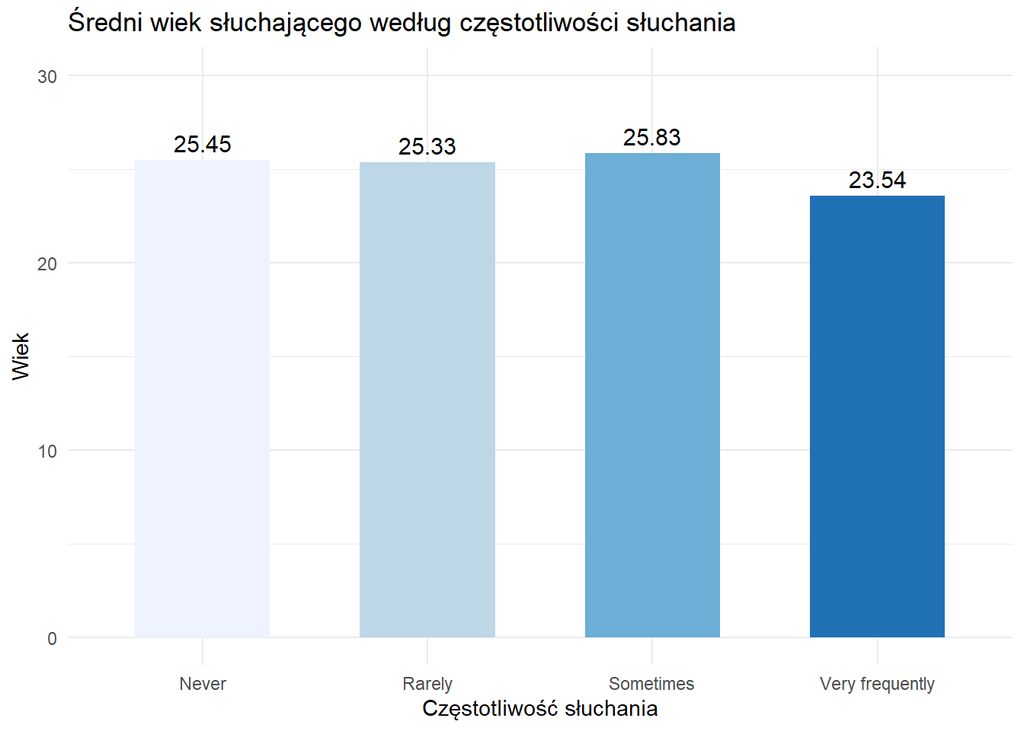

Można zauważyć, że osoby słuchające muzyki bardzo często są średnio wyraźnie młodsze (23.54) niż pozostałe grupy. W przypadku pozostałych kategorii – Never, Rarely i Sometimes – różnice są niewielkie i oscylują wokół 25–26 lat. Może to sugerować, że intensywne słuchanie muzyki jest szczególnie charakterystyczne dla młodszych osób, natomiast w starszych grupach wiekowych częstotliwość słuchania rozkłada się bardziej równomiernie.